# Trend Analysis for Projected Maximum and Minimum Temperature at Utah (USA) Ski Resorts

Hadia Akbar, Emily Wilkins

May 1, 2021

#### Load the libraries needed for this analysis

```r
library(ncdf4)    #to read the netcdf data
library(raster)   #to extract times series data from raster
library(tidyverse)#to mutate data, apply statistics
library(dplyr)
library(ggplot2)  #to plot
library(trend) # For Mann-Kendall trend test and Sen's slope
```

# 1- Data Download

We have saved the files downloaded from NA CORDEX needed for this analysis at a hydroshare repository. The next part download data from hydrosahre and unzips the files in the working directory.

```r
file <- "ClimateProjectionsData.zip"
url <- "https://www.hydroshare.org/resource/a1c6c9300f63482a95634996fa971454/data/contents/DataDownload/Climate Projections/ClimateProjectionsData.zip"
#Downloading might take some time (~15 minutes), be patient.
if (!file.exists(file)){
  download.file(url, file)
}
# If this does not work, manually download from the link above, unzip, and save to the working directory
```

```r
#Unzip the data files in the working directory. This again would take some time, ~5 min.
unzip(file)
```

# 2- Extracting Data

The NA CORDEX data comes as raster brick containing multi layers of data. The next part extracts data for the required area. As we need data for Utah, we will create a grid containing coordinates for Utah which will later be used to crop data for our area of interest.

```r
area<- extent(-115, -105, 35, 45)
#Also, setup a grid for Northern and Southern Utah.
##coordinates, by=interval
lon<- rep(seq(-112.5,-111,by=0.5), each=5)
lat <- rep(seq(40,42, 0.5),times=4)
north <- cbind(lon,lat)

lon<- rep(seq(-113.5,-112,by=0.5), each=5)
lat <- rep(seq(37,39, 0.5),times=4)
south <- cbind(lon,lat)
```

```r
#.rs.unloadPackage("tidyr")    #tidyr causes a conflict with raster package so we will unload the package.
#tidyverse_conflicts()
```

## 3- Projections for Maximum Temperature

### 3.1 - Maximum Temperature - RCP 2.6

We will first extract data for maximum temperature for RCP 2.6 scenario. Read data from file and extract data for Northern and Southern Utah using grid established in the last step.

```r
#file name
f<-  as.character("tasmax.rcp26.EC-EARTH.RCA4.mon.NAM-44i.raw.nc")

#The following line of code extracts data from the netcdf file for selected variable
Data <- raster::brick(f, varname="tasmax")

#Crop the data series for the selected area
a.crop<- crop(Data, area)
#Extract data for Northern Utah
Ext_North<- data.frame(raster::extract(a.crop, north, method="bilinear"))

#Create a time series from the extracted data
North <- data.frame(Years= Data@z$Date, Tmax=colMeans(Ext_North, na.rm=TRUE))
##convert from K to degC
North$Tmax_C <- North$Tmax -273
```

Create a cleaned up copy of the data from last step as a tibble, this is required for calculations to be done for December - March

```r
NUtah<- tibble(
  date = seq(as.Date('2006-01-01'), as.Date('2100-12-16'), by='month'),Tmax = North$Tmax_C)

NUtah2.6<- NUtah %>%
  # reformat data to keep months and days, but use identical year, so...
  mutate(same_year = as.Date(format(date, '2006-%m-%d'))) %>%
  # This filters to only include December - March
  filter(same_year < as.Date('2006-04-01') | same_year >=as.Date('2006-11-30')) %>%
  # shift so all in one year and use for grouping
  group_by(run=as.integer(format(date-100, '%Y'))) %>%
  summarise(    # aggregate each group for the specified time
    start_date = min(date),
    end_date = max(date),
    Tmax_mean = mean(Tmax),
    P95 = quantile(Tmax, 0.95))

NUtah2.6 <-  NUtah2.6 %>%
  dplyr::select(run, Tmax_mean) %>%
  filter(run >= 2021)%>%
  mutate(RCP = "2.6")
```

Repeat the same procedure to get data for Southern Utah

```r
##extract data for the selected coordinates
Ext_South<- data.frame(raster::extract(a.crop, south, method="bilinear"))

South <- data.frame(Years= Data@z$Date, Tmax=colMeans(Ext_South, na.rm=TRUE))
##convert from K to degC
South$Tmax_C <- South$Tmax -273

SUtah<- tibble(
  date = seq(as.Date('2006-01-01'), as.Date('2100-12-16'), by='month'), Tmax = South$Tmax_C)

SUtah2.6<- SUtah %>%
  # reformat data to keep months and days, but use identical year, so...
  mutate(same_year = as.Date(format(date, '2006-%m-%d'))) %>%
  # Use the dates for the ski season here
  filter(same_year < as.Date('2006-04-01') | same_year >=as.Date('2006-11-30')) %>%
  # shift so all in one year and use for grouping
  group_by(run=as.integer(format(date-100, '%Y'))) %>%
  summarise(    # aggregate each gruop for the specified time
    start_date = min(date), end_date = max(date), Tmax_mean = mean(Tmax),
    P95 = quantile(Tmax, 0.95))

SUtah2.6 <-  SUtah2.6 %>%
  dplyr::select(run, Tmax_mean) %>%
  filter(run >= 2021)%>%
  mutate(RCP = "2.6")
```

## 3.2 - Maximum Temperature - RCP 4.5

```r
f<-  as.character("tasmax.rcp45.EC-EARTH.RCA4.mon.NAM-44i.raw.nc")
Data <- brick(f, varname="tasmax")

#Crop the data series for the selected area
a.crop<- crop(Data, area)

#North
##extract data for the selected coordinates
Ext_North<- data.frame(raster::extract(a.crop, north, method="bilinear"))

#Average for the entire area
North <- data.frame(Years= Data@z$Date, Tmax=colMeans(Ext_North, na.rm=TRUE))
##convert from K to degC
North$Tmax_C <- North$Tmax -273

#Create a cleaned up copy of the data from last step as a tibble, this is
#required for calculations to be done for November - March
NUtah<- tibble(
  date = seq(as.Date('2006-01-01'), as.Date('2100-12-16'), by = 'month'),
  Tmax = North$Tmax_C)

NUtah4.5<- NUtah %>%
  # reformat data to keep months and days, but use identical year.
  mutate(same_year = as.Date(format(date, '2006-%m-%d'))) %>%
  # Use the dates for the ski season here
  filter(same_year < as.Date('2006-04-01') | same_year >=as.Date('2006-11-30')) %>%
  # shift so all in one year and use for grouping
  group_by(run=as.integer(format(date-100, '%Y'))) %>%
  summarise(    # aggregate each gruop for the specified time
    start_date = min(date), end_date = max(date), Tmax_mean = mean(Tmax),
    P95 = quantile(Tmax, 0.95))

NUtah4.5 <-  NUtah4.5 %>%
  dplyr::select(run, Tmax_mean) %>%
  filter(run >= 2021)%>%
  mutate(RCP = "4.5")

#Repeat the same for extracting data for Southern Utah
Ext_South<- data.frame(raster::extract(a.crop, south, method="bilinear"))

#Average for the entire area
South <- data.frame(Years= Data@z$Date, Tmax=colMeans(Ext_South, na.rm=TRUE))
##convert from K to degC
South$Tmax_C <- South$Tmax -273

#Create a cleaned up copy of the data from last step as a tibble, this is required for calculations to be done for November - March
SUtah<- tibble(
  date = seq(as.Date('2006-01-01'), as.Date('2100-12-16'), by = 'month'),   Tmax = South$Tmax_C)

SUtah4.5<- SUtah %>%
  # reformat data to keep months and days, but use identical year, so...
  mutate(same_year = as.Date(format(date, '2006-%m-%d'))) %>%
  # Use the dates for the ski season here
  filter(same_year < as.Date('2006-04-01') | same_year >=as.Date('2006-11-30')) %>%
  # shift so all in one year and use for grouping
  group_by(run=as.integer(format(date-100, '%Y'))) %>%
  summarise(    # aggregate each gruop for the specified time
    start_date = min(date), end_date = max(date), Tmax_mean = mean(Tmax),
    P95 = quantile(Tmax, 0.95))

SUtah4.5<-  SUtah4.5 %>%
  dplyr::select(run, Tmax_mean) %>%
  filter(run >= 2021)%>%
  mutate(RCP = "4.5")
```

## 3.3 - Maximimum Temperature - RCP 8.5

```r
f<-  as.character("tasmax.rcp85.EC-EARTH.RCA4.mon.NAM-44i.raw.nc")

#The following line of code extracts data from the netcdf file
#Get data for Tmax projections RCP_8.5
Data <- brick(f, varname="tasmax")

#Crop the data series for the selected area
a.crop<- crop(Data, area)

#North
##extract data for the selected coordinates
Ext_North<- data.frame(raster::extract(a.crop, north, method="bilinear"))

#Average for the entire area
North <- data.frame(Years= Data@z$Date, Tmax=colMeans(Ext_North, na.rm=TRUE))
##convert from K to degC
North$Tmax_C <- North$Tmax -273

#Create a cleaned up copy of the data from last step as a tibble, this is
#required for calculations to be done for November - March
NUtah<- tibble(
  date = seq(as.Date('2006-01-01'), as.Date('2100-12-16'), by = 'month'),
  Tmax = North$Tmax_C)

NUtah8.5<- NUtah %>%
  # reformat data to keep months and days, but use identical year, so...
  mutate(same_year = as.Date(format(date, '2006-%m-%d'))) %>%
  # Use the dates for the ski season here
  filter(same_year < as.Date('2006-04-01') | same_year >=as.Date('2006-11-30')) %>%
  # shift so all in one year and use for grouping
  group_by(run=as.integer(format(date-100, '%Y'))) %>%
  summarise(    # aggregate each gruop for the specified time
    start_date = min(date), end_date = max(date), Tmax_mean = mean(Tmax),
    P95 = quantile(Tmax, 0.95))

NUtah8.5 <-  NUtah8.5 %>%
  dplyr::select(run, Tmax_mean) %>%
  filter(run >= 2021)%>%
  mutate(RCP = "8.5")

#Repeat the same for extracting data for Southern Utah
##extract data for the selected coordinates
Ext_South<- data.frame(raster::extract(a.crop, south, method="bilinear"))

#Average for the entire area
South <- data.frame(Years= Data@z$Date, Tmax=colMeans(Ext_South, na.rm=TRUE))
##convert from K to degC
South$Tmax_C <- South$Tmax -273

#Create a cleaned up copy of the data from last step as a tibble, this is
#required for calculations to be done for November - March
SUtah<- tibble(
  date = seq(as.Date('2006-01-01'), as.Date('2100-12-16'), by = 'month'),
  Tmax = South$Tmax_C)

SUtah8.5 <- SUtah %>%
  # reformat data to keep months and days, but use identical year, so...
  mutate(same_year = as.Date(format(date, '2006-%m-%d'))) %>%
  # Use the dates for the ski season here
  filter(same_year < as.Date('2006-04-01') | same_year >=as.Date('2006-11-30')) %>%
  # shift so all in one year and use for grouping
  group_by(run=as.integer(format(date-100, '%Y'))) %>%
  summarise(    # aggregate each gruop for the specified time
    start_date = min(date), end_date = max(date), Tmax_mean = mean(Tmax),
    P95 = quantile(Tmax, 0.95))

SUtah8.5 <- SUtah8.5 %>%
  dplyr::select(run, Tmax_mean) %>%
  filter(run >= 2021)%>%
  mutate(RCP = "8.5")
```

Combine the data for Northern Utah and Southern Utah.

```r
NUtah <- rbind(NUtah2.6, NUtah4.5, NUtah8.5)
NUtah$Region <- c("Northern Utah")
SUtah <- rbind(SUtah2.6, SUtah4.5, SUtah8.5)
SUtah$Region <- c("Southern Utah")
Combined_Tmax <- rbind(NUtah, SUtah)

# Filter out year 2100 since this would represent the 2100-2101 ski season, and we don't have 2101 data (so it's not accurate)
Combined_Tmax <- Combined_Tmax %>% dplyr::filter(run != 2100)
```

Plot the projections for Northern and Southern Utah for the three RCP Scenarios

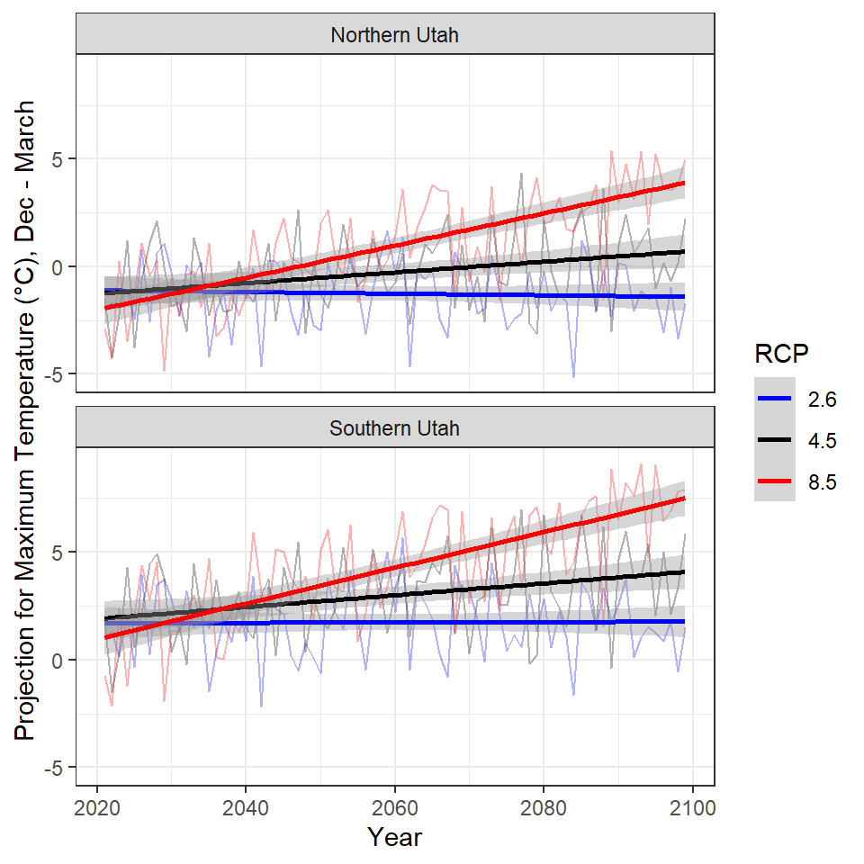

```r
a <- ggplot(Combined_Tmax,
           aes(x=run,y=Tmax_mean, color=RCP)) +
  scale_color_manual(values = c("blue", "black", "red"))+
  geom_line(alpha=0.3)+
  geom_smooth(method = "lm")+
  labs(#title= "Future Projection for Maximum Temperature- 95th Percentile (Dec-March)",
    y = "Projection for Maximum Temperature (°C), Dec - March", x = "Year") +
  xlim(2021,2099)+theme_bw()+
  facet_wrap(~ Region, ncol=1)
a
```

## Running Mann-Kendall Trend tests and Sen's slope for Max temp 2021 - 2100

```r
### Run Mann-Kendall Trend tests and Sen's slope

# Setting up an empty table to record results
table1 <- matrix(NA, nrow = 6, ncol = 12)
x <- c("RCP", "geo", "z stat", "S", "S var", "tau", "p-value", "sen's slope", "95% CI, low", "95% CI, high", "Change by 2100", "metric")
colnames(table1) <- x
table1 <- as.data.frame(table1)
table1[,1:2] <- as.character(table1[,1:2])

GEO <- c("Northern Utah","Northern Utah","Northern Utah", "Southern Utah", "Southern Utah", "Southern Utah")
RCP <- c("2.6", "4.5", "8.5", "2.6", "4.5", "8.5")

##### Max Temp M-K
for (i in 1:length(GEO)) {
  rcp <- as.character(RCP[i])  #choose scenario
  geo <- as.character(GEO[i]) # Chose geography

  data1 <- Combined_Tmax %>% dplyr::filter(RCP == rcp) %>% dplyr::filter(Region == geo) #Filters the database to only have data from this geo and RCP
  maxtemp <- trend::mk.test(data1$Tmax_mean, continuity = TRUE) # Runs Mann-Kendall trend test
  sen <- sens.slope(data1$Tmax_mean, conf.level = 0.95)
  # Fill in the table
  table1[i,1] <- rcp
  table1[i,2] <- geo
  table1[i,3] <- maxtemp$statistic # records z statistic
  table1[i,4] <- maxtemp$estimates[1] # records S
  table1[i,5] <- maxtemp$estimates[2] # records variance on S
  table1[i,6] <- maxtemp$estimates[3] # records tau
  table1[i,7] <- maxtemp$p.value # records p-value
  table1[i,8] <- sen$estimates # records Sen's slope
  table1[i,9] <- sen$conf.int[1] # records CI
  table1[i,10] <- sen$conf.int[2] # records CI
  table1[i,11] <- (sen$estimates) * 78
  table1[i,12] <- "Mean Seasonal Daily Max Temp Projection"
}

# Rounds everything to 3 decimals
table1[,3:11] <- round(table1[,3:11], 3)
table1
```

| RCP | geo | z stat | S | S var | tau | p-value | sen's slope | 95% CI, low | 95% CI, high | Change by 2100 | metric |
| --- | --- | --- | --- | --- | --- | --- | --- | --- | --- | --- | --- |
| 2.6 | Northern Utah | -0.559 | -133 | 55800.33 | -0.043 | 0.576 | -0.004 | -0.019 | 0.011 | -0.306 | Mean Seasonal Daily Max Temp Projection |
| 4.5 | Northern Utah | 2.625 | 621 | 55800.33 | 0.202 | 0.009 | 0.026 | 0.007 | 0.045 | 2.041 | Mean Seasonal Daily Max Temp Projection |
| 8.5 | Northern Utah | 6.892 | 1629 | 55800.33 | 0.529 | 0.000 | 0.076 | 0.061 | 0.093 | 5.964 | Mean Seasonal Daily Max Temp Projection |
| 2.6 | Southern Utah | -0.059 | -15 | 55800.33 | -0.005 | 0.953 | -0.001 | -0.017 | 0.017 | -0.063 | Mean Seasonal Daily Max Temp Projection |
| 4.5 | Southern Utah | 2.735 | 647 | 55800.33 | 0.210 | 0.006 | 0.030 | 0.009 | 0.048 | 2.323 | Mean Seasonal Daily Max Temp Projection |
| 8.5 | Southern Utah | 6.993 | 1653 | 55800.33 | 0.537 | 0.000 | 0.084 | 0.066 | 0.103 | 6.580 | Mean Seasonal Daily Max Temp Projection |

```r
# Output table if desired
# write.csv(table1, "M_K_trends_maxtemp_PROJECTION.csv", row.names = FALSE)
```

## 4- Projections for Minimum Temperature

### 4.1 - Minimimum Temperature - RCP 2.6

```r
f<-  as.character("tasmin.rcp26.EC-EARTH.RCA4.mon.NAM-44i.raw.nc")

Data <- brick(f, varname="tasmin")
a.crop<- crop(Data, area)

Ext_North<- data.frame(raster::extract(a.crop, north, method="bilinear"))

North <- data.frame(Years= Data@z$Date, Tmin=colMeans(Ext_North, na.rm=TRUE))

##convert from K to degC
North$Tmin_C <- North$Tmin -273

NUtah<- tibble(
  date = seq(as.Date('2006-01-01'), as.Date('2100-12-16'), by = 'month'),
  Tmin = North$Tmin_C)

NUtah2.6<- NUtah %>%
  mutate(same_year = as.Date(format(date, '2006-%m-%d'))) %>%
  filter(same_year < as.Date('2006-04-01') | same_year >=as.Date('2006-11-30')) %>%
  group_by(run=as.integer(format(date-100, '%Y'))) %>%
  summarise(start_date = min(date), end_date = max(date), Tmin_mean = mean(Tmin),
    P95 = quantile(Tmin, 0.95))

NUtah2.6 <-  NUtah2.6 %>%
  dplyr::select(run, Tmin_mean) %>%
  filter(run >= 2021)%>%
  mutate(RCP = "2.6")

Ext_South<- data.frame(raster::extract(a.crop, south, method="bilinear"))

South <- data.frame(Years= Data@z$Date, Tmin=colMeans(Ext_South, na.rm=TRUE))

##convert from K to degC
South$Tmin_C <- South$Tmin -273

SUtah<- tibble(
  date = seq(as.Date('2006-01-01'), as.Date('2100-12-16'), by = 'month'),
  Tmin = South$Tmin_C)

SUtah2.6<- SUtah %>%
  mutate(same_year = as.Date(format(date, '2006-%m-%d'))) %>%
  filter(same_year < as.Date('2006-04-01') | same_year >=as.Date('2006-11-30')) %>%
  group_by(run=as.integer(format(date-100, '%Y'))) %>%
  summarise(start_date = min(date), end_date = max(date), Tmin_mean = mean(Tmin),
    P95 = quantile(Tmin, 0.95))

SUtah2.6 <-  SUtah2.6 %>%
  dplyr::select(run, Tmin_mean) %>%
  filter(run >= 2021)%>%
  mutate(RCP = "2.6")
```

### 4.2 - Minimimum Temperature - RCP 4.5

```r
f<-  as.character("tasmin.rcp45.EC-EARTH.RCA4.mon.NAM-44i.raw.nc")
Data <- brick(f, varname="tasmin")
a.crop<- crop(Data, area)

Ext_North<- data.frame(raster::extract(a.crop, north, method="bilinear"))

North <- data.frame(Years= Data@z$Date, Tmin=colMeans(Ext_North, na.rm=TRUE))
##convert from K to degC
North$Tmin_C <- North$Tmin -273

NUtah<- tibble(
  date = seq(as.Date('2006-01-01'), as.Date('2100-12-16'),
             by= 'month'), Tmin = North$Tmin_C)

NUtah4.5<- NUtah %>%
  mutate(same_year = as.Date(format(date, '2006-%m-%d'))) %>%
  filter(same_year < as.Date('2006-04-01') |
           same_year >=as.Date('2006-11-30')) %>%
  group_by(run=as.integer(format(date-100, '%Y'))) %>%
  summarise(start_date = min(date), end_date = max(date), Tmin_mean = mean(Tmin),
    P95 = quantile(Tmin, 0.95))

NUtah4.5 <-  NUtah4.5 %>%
  dplyr::select(run, Tmin_mean) %>%
  filter(run >= 2021)%>%
  mutate(RCP = "4.5")

Ext_South<- data.frame(raster::extract(a.crop, south, method="bilinear"))

South <- data.frame(Years= Data@z$Date, Tmin=colMeans(Ext_South, na.rm=TRUE))
##convert from K to degC
South$Tmin_C <- South$Tmin -273

SUtah<- tibble(
  date = seq(as.Date('2006-01-01'), as.Date('2100-12-16'),
             by = 'month'), Tmin = South$Tmin_C)

SUtah4.5<- SUtah %>%
  mutate(same_year = as.Date(format(date, '2006-%m-%d'))) %>%
  filter(same_year < as.Date('2006-04-01') | same_year >=as.Date('2006-11-30')) %>%
  group_by(run=as.integer(format(date-100, '%Y'))) %>%
  summarise(start_date = min(date), end_date = max(date), Tmin_mean = mean(Tmin),
    P95 = quantile(Tmin, 0.95))

SUtah4.5<-  SUtah4.5 %>%
  dplyr::select(run, Tmin_mean) %>%
  filter(run >= 2021)%>%
  mutate(RCP = "4.5")
```

### 4.3 - Minimimum Temperature - RCP 8.5

```r
f<-  as.character("tasmin.rcp85.EC-EARTH.RCA4.mon.NAM-44i.raw.nc")

Data <- brick(f, varname="tasmin")
a.crop<- crop(Data, area)

Ext_North<- data.frame(raster::extract(a.crop, north, method="bilinear"))

North <- data.frame(Years= Data@z$Date, Tmin=colMeans(Ext_North, na.rm=TRUE))
##convert from K to degC
North$Tmin_C <- North$Tmin -273

NUtah<- tibble(
  date = seq(as.Date('2006-01-01'), as.Date('2100-12-16'), by = 'month'), Tmin = North$Tmin_C)

NUtah8.5<- NUtah %>%
  mutate(same_year = as.Date(format(date, '2006-%m-%d'))) %>%
  filter(same_year < as.Date('2006-04-01') | same_year >=as.Date('2006-11-30')) %>%
  group_by(run=as.integer(format(date-100, '%Y'))) %>%
  summarise(start_date = min(date), end_date = max(date), Tmin_mean = mean(Tmin),
    P95 = quantile(Tmin, 0.95))

NUtah8.5 <-  NUtah8.5 %>%
  dplyr::select(run, Tmin_mean) %>%
  filter(run >= 2021)%>%
  mutate(RCP = "8.5")

Ext_South<- data.frame(raster::extract(a.crop, south, method="bilinear"))

South <- data.frame(Years= Data@z$Date, Tmin=colMeans(Ext_South, na.rm=TRUE))
##convert from K to degC
South$Tmin_C <- South$Tmin -273

SUtah<- tibble(
  date = seq(as.Date('2006-01-01'), as.Date('2100-12-16'),
             by = 'month'), Tmin = South$Tmin_C)

SUtah8.5<- SUtah %>%
  mutate(same_year = as.Date(format(date, '2006-%m-%d'))) %>%
  filter(same_year < as.Date('2006-04-01') |
           same_year >=as.Date('2006-11-30')) %>%
  group_by(run=as.integer(format(date-100, '%Y'))) %>%
  summarise(start_date = min(date), end_date = max(date), Tmin_mean = mean(Tmin),
    P95 = quantile(Tmin, 0.95))

SUtah8.5<-  SUtah8.5 %>%
  dplyr::select(run, Tmin_mean) %>%
  filter(run >= 2021)%>%
  mutate(RCP = "8.5")
```

Combine the data for Northern and Southern Utah.

```r
NUtah <- rbind(NUtah2.6, NUtah4.5, NUtah8.5)
NUtah$Region <- c("Northern Utah")
SUtah <- rbind(SUtah2.6, SUtah4.5, SUtah8.5)
SUtah$Region <- c("Southern Utah")
Combined_Tmin <- rbind(NUtah, SUtah)

# Filter out year 2100 since this would represent the 2100-2101 ski season, and we don't have 2101 data (so it's not accurate)
Combined_Tmin <- Combined_Tmin %>% dplyr::filter(run != 2100)
```

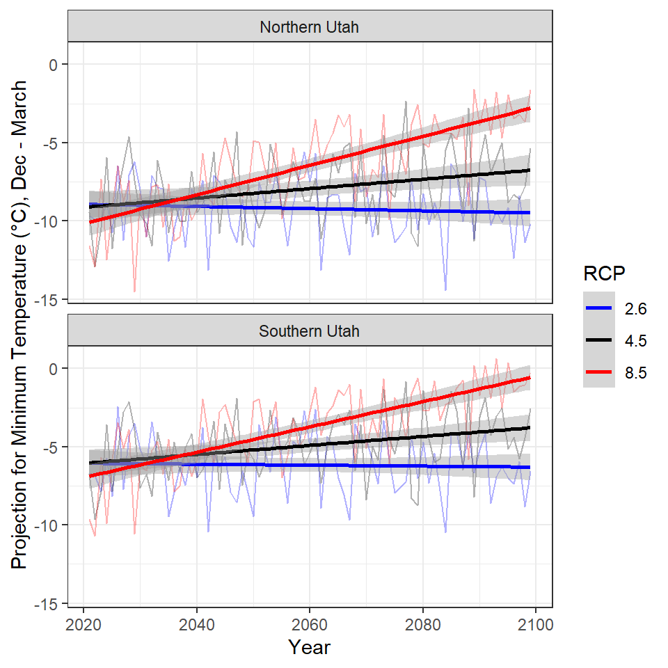

```r
b <- ggplot(Combined_Tmin,
            aes(x=run,y=Tmin_mean, color=RCP)) +
  scale_color_manual(values = c("blue", "black", "red"))+
  geom_line(alpha=0.3)+
  geom_smooth(method = "lm")+
  labs(
    #title= "Future Projection for Minimum Temperature- 95th Percentile (Dec-March)",
    y = "Projection for Minimum Temperature (°C), Dec - March", x = "Year") +
  xlim(2021,2099)+theme_bw()+
  facet_wrap(~ Region, ncol=1) # if removed, x ticks don't show in all plots
b
```

```r
# Uncomment if you want to save the plots
# ggsave("projection_Tmax_new.tiff", plot= a , height=5 , width=5 , units= "in", dpi= 600)
# ggsave("projection_Tmin_new.tiff", plot= b , height=5 , width=5 , units= "in", dpi= 600)
```

## Running Mann-Kendall Trend tests and Sen's slope for Min temp 2021 - 2100

```r
### Run Mann-Kendall Trend tests and Sen's slope

# Setting up an empty table to record results
table1 <- matrix(NA, nrow = 6, ncol = 12)
x <- c("RCP", "geo", "z stat", "S", "S var", "tau", "p-value", "sen's slope", "95% CI, low", "95% CI, high", "Change by 2100", "metric")
colnames(table1) <- x
table1 <- as.data.frame(table1)
table1[,1:2] <- as.character(table1[,1:2])

GEO <- c("Northern Utah","Northern Utah","Northern Utah", "Southern Utah", "Southern Utah", "Southern Utah")
RCP <- c("2.6", "4.5", "8.5", "2.6", "4.5", "8.5")

##### Max Temp M-K
for (i in 1:length(GEO)) {
  rcp <- as.character(RCP[i])  #choose scenario
  geo <- as.character(GEO[i]) # Chose geography

  data1 <- Combined_Tmin %>% dplyr::filter(RCP == rcp) %>% dplyr::filter(Region == geo) #Filters the database to only have data from this geo and RCP
  maxtemp <- trend::mk.test(data1$Tmin_mean, continuity = TRUE) # Runs Mann-Kendall trend test
  sen <- sens.slope(data1$Tmin_mean, conf.level = 0.95)
  # Fill in the table
  table1[i,1] <- rcp
  table1[i,2] <- geo
  table1[i,3] <- maxtemp$statistic # records z statistic
  table1[i,4] <- maxtemp$estimates[1] # records S
  table1[i,5] <- maxtemp$estimates[2] # records variance on S
  table1[i,6] <- maxtemp$estimates[3] # records tau
  table1[i,7] <- maxtemp$p.value # records p-value
  table1[i,8] <- sen$estimates # records Sen's slope
  table1[i,9] <- sen$conf.int[1] # records CI
  table1[i,10] <- sen$conf.int[2] # records CI
  table1[i,11] <- (sen$estimates) * 78
  table1[i,12] <- "Mean Seasonal Daily Min Temp Projection"
}

# Rounds everything to 3 decimals
table1[,3:11] <- round(table1[,3:11], 3)
table1
```

| RCP | geo | z stat | S | S var | tau | p-value | sen's slope | 95% CI, low | 95% CI, high | Change by 2100 | metric |
| --- | --- | --- | --- | --- | --- | --- | --- | --- | --- | --- | --- |
| 2.6 | Northern Utah | -0.728 | -173 | 55800.33 | -0.056 | 0.467 | -0.007 | -0.029 | 0.013 | -0.538 | Mean Seasonal Daily Min Temp Projection |
| 4.5 | Northern Utah | 2.548 | 603 | 55800.33 | 0.196 | 0.011 | 0.031 | 0.008 | 0.054 | 2.402 | Mean Seasonal Daily Min Temp Projection |
| 8.5 | Northern Utah | 7.281 | 1721 | 55800.33 | 0.559 | 0.000 | 0.094 | 0.073 | 0.113 | 7.334 | Mean Seasonal Daily Min Temp Projection |
| 2.6 | Southern Utah | -0.237 | -57 | 55800.33 | -0.019 | 0.813 | -0.002 | -0.023 | 0.019 | -0.175 | Mean Seasonal Daily Min Temp Projection |
| 4.5 | Southern Utah | 2.929 | 693 | 55800.33 | 0.225 | 0.003 | 0.031 | 0.012 | 0.051 | 2.417 | Mean Seasonal Daily Min Temp Projection |
| 8.5 | Southern Utah | 7.002 | 1655 | 55800.33 | 0.537 | 0.000 | 0.078 | 0.061 | 0.096 | 6.107 | Mean Seasonal Daily Min Temp Projection |

```r
# Output table if desired
# write.csv(table1, "M_K_trends_mintemp_PROJECTION.csv", row.names = FALSE)
```

## 5- Projections for Precipitation

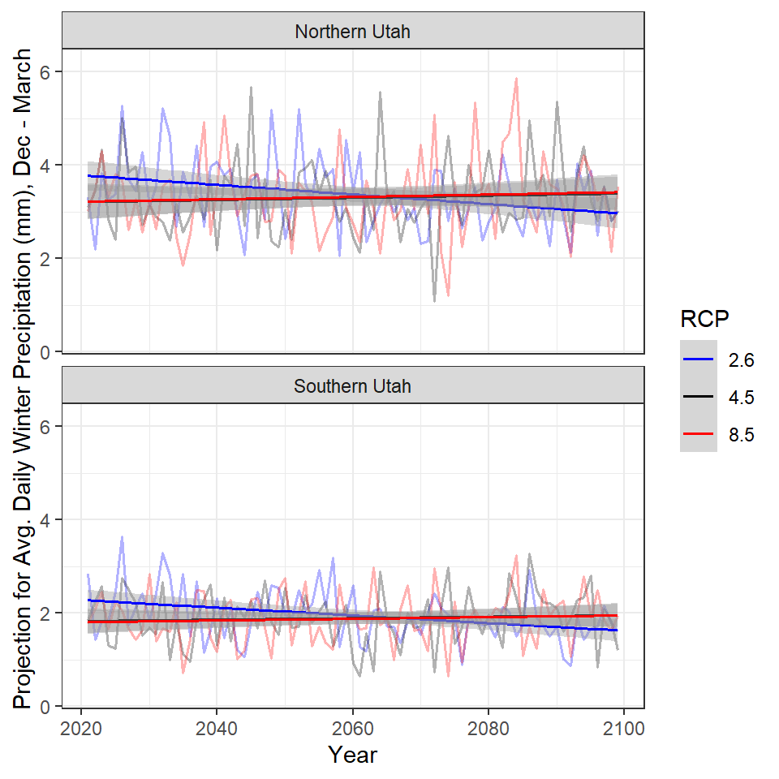

```r
### RCP 2.6
f<-  as.character("pr.rcp26.EC-EARTH.RCA4.mon.NAM-44i.raw.nc")

#The following line of code actutally extracts data from the netcdf file, Precipitation projections RCP_2.6
Data <- brick(f, varname="pr")

#Get a grid of your area of interest (can be area of study or a larger grid)
area<- extent(-115, -105, 35,45)
a.crop<- crop(Data, area)

#North
#Get the data for coordinates of interest, that should be equal to or a subset of the previously mentioned grid
##coordinates, by=the interval
lon<- rep(seq(-112.5,-111,by=0.5), each=5)
lat <- rep(seq(40,42, 0.5),times=4)
coord <- cbind(lon,lat)

##extract data for the selected coordinates
Data_Ext<- data.frame(raster::extract(a.crop, coord, method="bilinear"))

#Average for the entire area
North <- data.frame(Years= Data@z$Date, Ppt=colMeans(Data_Ext, na.rm=TRUE))
##convert from kg.m2.s-1 to mm/day
North$North <- North$Ppt*86400

#Create data in tibble, this is required for calculations to be done
#by resort season
NUtah<- tibble(
  date = seq(as.Date('2006-01-01'), as.Date('2100-12-16'), by = 'month'),
  Ppt= North$North)

NUtah2.6<- NUtah %>%
  # reformat data to keep months and days, but use identical year, so...
  mutate(same_year = as.Date(format(date, '2006-%m-%d'))) %>%
  # Use the dates for the ski season here
  filter(same_year < as.Date('2006-04-01') | same_year >=as.Date('2006-11-30')) %>%
  # shift so all in one year and use for grouping
  group_by(run=as.integer(format(date-250, '%Y'))) %>%
  summarise(    # aggregate each gruop for the specified time Pptiod
    start_date = min(date), end_date = max(date),
   Precip = mean(Ppt))
#write.csv(NUtah26 , "NUtah_Ppt2.6.csv")

NUtah2.6$start_date<- NULL
NUtah2.6$end_date <- NULL

#South
#Get the data for coordinates of interest , that should be equal to or a subset of the previously mentioned grid
##coordinates, by=the interval
lon<- rep(seq(-113.5,-112,by=0.5), each=5)
lat <- rep(seq(37,39, 0.5),times=4)
coord <- cbind(lon,lat)
##extract data for the selected coordinates
Data_Ext<- data.frame(raster::extract(a.crop, coord, method="bilinear"))

#Average for the entire area
South <- data.frame(Years= Data@z$Date, Ppt=colMeans(Data_Ext, na.rm=TRUE))
##convert from kg.m2.s-1 to mm/day
South$South <- South$Ppt*86400

#Create data in tibble, this is required for calculations to be done by resort season
SUtah<- tibble(
  date = seq(as.Date('2006-01-01'), as.Date('2100-12-16'), by = 'month'),
  Ppt= South$South)

SUtah2.6<- SUtah %>%
  # reformat data to keep months and days, but use identical year, so...
  mutate(same_year = as.Date(format(date, '2006-%m-%d'))) %>%
  # Use the dates for the ski season here
  filter(same_year < as.Date('2006-04-01') | same_year >=as.Date('2006-11-30')) %>%
  # shift so all in one year and use for grouping
  group_by(run=as.integer(format(date-250, '%Y'))) %>%
  summarise(    # aggregate each gruop for the specified time Pptiod
    start_date = min(date), end_date = max(date),
    Precip = mean(Ppt))
#write.csv(SUtah26 , "SUtah_Ppt2.6.csv")

SUtah2.6$start_date<- NULL
SUtah2.6$end_date <- NULL

###########################################
##Same procedure Precipitation for RCP 4.5
f<-  as.character("pr.rcp45.EC-EARTH.RCA4.mon.NAM-44i.raw.nc")

#The following line of code actutally extracts data from the netcdf file
Data <- brick(f, varname="pr")

#North
#Get a grid of your area of interest (can be area of study or a larger grid)
area<- extent(-115, -105, 35,45)
a.crop<- crop(Data, area)

#North
#Get the data for coordinates of interest , that should be equal to or a subset of the previously mentioned grid
##coordinates, by=the interval
lon<- rep(seq(-112.5,-111,by=0.5), each=5)
lat <- rep(seq(40,42, 0.5),times=4)
coord <- cbind(lon,lat)
##extract data for the selected coordinates
Data_Ext<- data.frame(raster::extract(a.crop, coord, method="bilinear"))

#Average for the entire area
North <- data.frame(Years= Data@z$Date, Ppt=colMeans(Data_Ext, na.rm=TRUE))
##convert from kg.m2.s-1 to mm/day
North$North <- North$Ppt*86400

#Create data in tibble, this is required for calculations to be done
#by resort season
NUtah<- tibble(
  date = seq(as.Date('2006-01-01'), as.Date('2100-12-16'), by = 'month'),
  Ppt= North$North)

NUtah4.5<- NUtah %>%
  # reformat data to keep months and days, but use identical year, so...
  mutate(same_year = as.Date(format(date, '2006-%m-%d'))) %>%
  # Use the dates for the ski season here
  filter(same_year < as.Date('2006-04-01') | same_year >=as.Date('2006-11-30')) %>%
  # shift so all in one year and use for grouping
  group_by(run=as.integer(format(date-250, '%Y'))) %>%
  summarise(    # aggregate each gruop for the specified time period
    start_date = min(date), end_date = max(date),
    Precip = mean(Ppt))
#View(NUtah8.5)
#write.csv(NUtah8.5 , "NUtah_Ppt8.5.csv")

NUtah4.5$start_date<- NULL
NUtah4.5$end_date <- NULL

#South
#Get the data for coordinates of interest , that should be equal to or a subset of the previously mentioned grid
##coordinates, by=the interval
lon<- rep(seq(-113.5,-112,by=0.5), each=5)
lat <- rep(seq(37,39, 0.5),times=4)
coord <- cbind(lon,lat)
##extract data for the selected coordinates
Data_Ext<- data.frame(raster::extract(a.crop, coord, method="bilinear"))

#Average for the entire area
South <- data.frame(Years= Data@z$Date, Ppt=colMeans(Data_Ext, na.rm=TRUE))
##convert from kg.m2.s-1 to mm/day
South$South <- South$Ppt*86400

#Create data in tibble, this is required for calculations to be done
#by resort season
SUtah<- tibble(
  date = seq(as.Date('2006-01-01'), as.Date('2100-12-16'), by = 'month'),
  Ppt= South$South)
SUtah4.5<- SUtah %>%
  # reformat data to keep months and days, but use identical year, so...
  mutate(same_year = as.Date(format(date, '2006-%m-%d'))) %>%
  # Use the dates for the ski season here
  filter(same_year < as.Date('2006-04-01') | same_year >=as.Date('2006-11-30')) %>%
  # shift so all in one year and use for grouping
  group_by(run=as.integer(format(date-250, '%Y'))) %>%
  summarise(    # aggregate each gruop for the specified time period
    start_date = min(date), end_date = max(date),
    Precip = mean(Ppt))
#write.csv(SUtah8.5 , "SUtah_Ppt8.5.csv")

SUtah4.5$start_date<- NULL
SUtah4.5$end_date <- NULL

##################################
##Same procedure for Precipitation RCP 8.5
f<-  as.character("pr.rcp85.EC-EARTH.RCA4.mon.NAM-44i.raw.nc")

#The following line of code actutally extracts data from the netcdf file
#Get data Precipitation projections RCP_8.5
Data <- brick(f, varname="pr")

#North
#Get a grid of your area of interest (can be area of study or a larger grid)
area<- extent(-115, -105, 35,45)
a.crop<- crop(Data, area)

#North
#Get the data for coordinates of interest , that should be equal to or a subset of the previously mentioned grid
##coordinates, by=the interval
lon<- rep(seq(-112.5,-111,by=0.5), each=5)
lat <- rep(seq(40,42, 0.5),times=4)
coord <- cbind(lon,lat)
##extract data for the selected coordinates
Data_Ext<- data.frame(raster::extract(a.crop, coord, method="bilinear"))

#Average for the entire area
North <- data.frame(Years= Data@z$Date, Ppt=colMeans(Data_Ext, na.rm=TRUE))
##convert from kg.m2.s-1 to mm/day
North$North <- North$Ppt*86400

#Create data in tibble, this is required for calculations to be done
#by resort season
NUtah<- tibble(
  date = seq(as.Date('2006-01-01'), as.Date('2100-12-16'), by = 'month'),
  Ppt= North$North)

NUtah8.5<- NUtah %>%
  # reformat data to keep months and days, but use identical year, so...
  mutate(same_year = as.Date(format(date, '2006-%m-%d'))) %>%
  # Use the dates for the ski season here
  filter(same_year < as.Date('2006-04-01') | same_year >=as.Date('2006-11-30')) %>%
  # shift so all in one year and use for grouping
  group_by(run=as.integer(format(date-250, '%Y'))) %>%
  summarise(    # aggregate each gruop for the specified time period
    start_date = min(date), end_date = max(date),
   Precip = mean(Ppt))
#View(NUtah8.5)
#write.csv(NUtah8.5 , "NUtah_Ppt8.5.csv")

NUtah8.5$start_date<- NULL
NUtah8.5$end_date <- NULL

#South
#Get the data for coordinates of interest , that should be equal to or a subset of the previously mentioned grid
##coordinates, by=the interval
lon<- rep(seq(-113.5,-112,by=0.5), each=5)
lat <- rep(seq(37,39, 0.5),times=4)
coord <- cbind(lon,lat)
##extract data for the selected coordinates
Data_Ext<- data.frame(raster::extract(a.crop, coord, method="bilinear"))

#Average for the entire area
South <- data.frame(Years= Data@z$Date, Ppt=colMeans(Data_Ext, na.rm=TRUE))
##convert from kg.m2.s-1 to mm/day
South$South <- South$Ppt*86400

#Create data in tibble, this is required for calculations to be done
#by resort season
SUtah<- tibble(
  date = seq(as.Date('2006-01-01'), as.Date('2100-12-16'), by = 'month'),
  Ppt= South$South)
SUtah8.5<- SUtah %>%
  # reformat data to keep months and days, but use identical year, so...
  mutate(same_year = as.Date(format(date, '2006-%m-%d'))) %>%
  # Use the dates for the ski season here
  filter(same_year < as.Date('2006-04-01') | same_year >=as.Date('2006-11-30')) %>%
  # shift so all in one year and use for grouping
  group_by(run=as.integer(format(date-250, '%Y'))) %>%
  summarise(    # aggregate each gruop for the specified time period
    start_date = min(date), end_date = max(date),
    Precip = mean(Ppt))
#write.csv(SUtah8.5 , "SUtah_Ppt8.5.csv")

SUtah8.5$start_date<- NULL
SUtah8.5$end_date <- NULL

NUtah2.6$RCP <- c("2.6")
NUtah8.5$RCP <- c("8.5")
NUtah4.5$RCP <- c("4.5")
SUtah2.6$RCP <- c("2.6")
SUtah8.5$RCP <- c("8.5")
SUtah4.5$RCP <- c("4.5")

NUtah <- rbind(NUtah2.6, NUtah8.5, NUtah4.5)
NUtah$Region <- "Northern Utah"
SUtah <- rbind(SUtah2.6, SUtah8.5, SUtah4.5)
SUtah$Region <- "Southern Utah"
all_precip <- rbind(NUtah, SUtah)
# Filter out year 2100 since this would represent the 2100-2101 ski season, and we don't have 2101 data (so it's not accurate)
Combined_precip <- all_precip %>% dplyr::filter(run != 2100) %>% dplyr::filter(run > 2020)

# Figure
precip_fig <- ggplot(all_precip,
            aes(x=run,y=Precip, color=RCP)) +
  scale_color_manual(values = c("blue", "black", "red"))+
  geom_line(alpha=0.3, lwd = 0.6)+
  geom_smooth(method = "lm", lwd = 0.6)+
  labs(y = "Projection for Avg. Daily Winter Precipitation (mm), Dec - March", x = "Year") +
  xlim(2021,2099)+ theme_bw()+
  facet_wrap(~ Region, ncol=1) # if removed, x ticks don't show in all plots
precip_fig
```

```r
# Save it if desired
# ggsave("projection_precip_new.tiff", plot= precip_fig , height=5 , width=5 , units= "in", dpi= 600)



###############
### Run Mann-Kendall Trend tests and Sen's slope

# Setting up an empty table to record results
table1 <- matrix(NA, nrow = 6, ncol = 12)
x <- c("RCP", "geo", "z stat", "S", "S var", "tau", "p-value", "sen's slope", "95% CI, low", "95% CI, high", "Change by 2100", "metric")
colnames(table1) <- x
table1 <- as.data.frame(table1)
table1[,1:2] <- as.character(table1[,1:2])

GEO <- c("Northern Utah","Northern Utah","Northern Utah", "Southern Utah", "Southern Utah", "Southern Utah")
RCP <- c("2.6", "4.5", "8.5", "2.6", "4.5", "8.5")

##### Max Temp M-K
for (i in 1:length(GEO)) {
  rcp <- as.character(RCP[i])  #choose scenario
  geo <- as.character(GEO[i]) # Chose geography

  data1 <- Combined_precip %>% dplyr::filter(RCP == rcp) %>% dplyr::filter(Region == geo) #Filters the database to only have data from this geo and RCP
  maxtemp <- trend::mk.test(data1$Precip, continuity = TRUE) # Runs Mann-Kendall trend test
  sen <- sens.slope(data1$Precip, conf.level = 0.95)
  # Fill in the table
  table1[i,1] <- rcp
  table1[i,2] <- geo
  table1[i,3] <- maxtemp$statistic # records z statistic
  table1[i,4] <- maxtemp$estimates[1] # records S
  table1[i,5] <- maxtemp$estimates[2] # records variance on S
  table1[i,6] <- maxtemp$estimates[3] # records tau
  table1[i,7] <- maxtemp$p.value # records p-value
  table1[i,8] <- sen$estimates # records Sen's slope
  table1[i,9] <- sen$conf.int[1] # records CI
  table1[i,10] <- sen$conf.int[2] # records CI
  table1[i,11] <- (sen$estimates) * 78
  table1[i,12] <- "Precipitation Projection (daily mm by season)"
}

# Rounds everything to 3 decimals
table1[,3:11] <- round(table1[,3:11], 3)
table1
```

| RCP | geo | z stat | S | S var | tau | p-value | sen's slope | 95% CI, low | 95% CI, high | Change by 2100 | metric |
| --- | --- | --- | --- | --- | --- | --- | --- | --- | --- | --- | --- |
| 2.6 | Northern Utah | -2.642 | -625 | 55800.33 | -0.203 | 0.008 | -0.010 | -0.018 | -0.003 | -0.755 | Precipitation Projection (daily mm by season) |
| 4.5 | Northern Utah | 0.754 | 179 | 55800.33 | 0.058 | 0.451 | 0.003 | -0.005 | 0.010 | 0.245 | Precipitation Projection (daily mm by season) |
| 8.5 | Northern Utah | 0.406 | 97 | 55800.33 | 0.031 | 0.684 | 0.002 | -0.006 | 0.011 | 0.124 | Precipitation Projection (daily mm by season) |
| 2.6 | Southern Utah | -2.921 | -691 | 55800.33 | -0.224 | 0.003 | -0.008 | -0.013 | -0.002 | -0.610 | Precipitation Projection (daily mm by season) |
| 4.5 | Southern Utah | 0.584 | 139 | 55800.33 | 0.045 | 0.559 | 0.001 | -0.005 | 0.008 | 0.114 | Precipitation Projection (daily mm by season) |
| 8.5 | Southern Utah | 0.720 | 171 | 55800.33 | 0.056 | 0.472 | 0.002 | -0.004 | 0.008 | 0.177 | Precipitation Projection (daily mm by season) |

```r
# Output table if desired
# write.csv(table1, "M_K_trends_precip_PROJECTION.csv", row.names = FALSE)
```